# Boston Air Pollution By Neighborhood Socioeconomic Status

Annie Lott

2022-05-30

In this project, I am investigating the relationship between historical nitrogen oxide air pollution in Boston with the past socioeconomic status of each neighborhood. This data was collected in the 1970’s, so this analysis is not current and is being used for demonstration purposes only.

Below I present some code to create box plots of the nitrogen oxide air pollution concentration, in parts per 10 million, based on whether the neighborhoods had above the median percentage of low socioeconomic status households within the neighborhood boundaries, or had above the median of percentage of low socioeconomic status households.

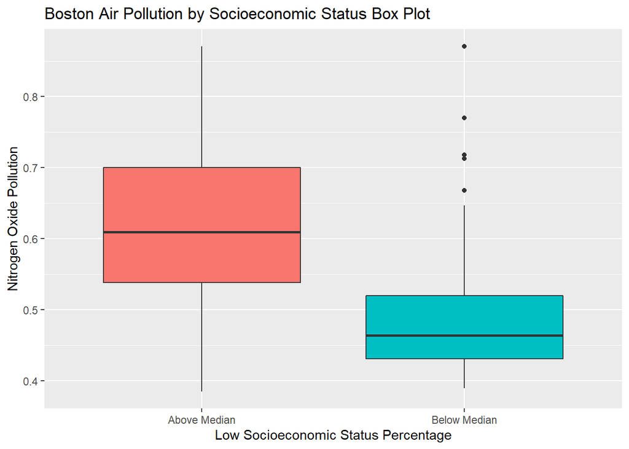

```r
#load libraries
library(MASS)
library(ggplot2)

#assign the Boston data set to df
df = Boston

#create a column that shows whether the low socioeconomic status
#percentage is below or above the median
df$lstat.med = ifelse(df$lstat > median(df$lstat), "Above Median",
                      "Below Median")

#make a box plot of the air pollution by socioeconomic status
ggplot(df)+
  geom_boxplot(aes(x = lstat.med, y = nox, fill = lstat.med)) +
  labs(x = "Low Socioeconomic Status Percentage",
       y = "Nitrogen Oxide Pollution",
       title = "Boston Air Pollution by Socioeconomic Status Box Plot") +
  theme(legend.position = "none")
```

Next I compare the mean nitrogen oxide air pollution of neighborhoods with above the median percentage of low socioeconomic status households, and below the median percentage of low socioeconomic status households. I then conduct a t-test to see if the difference of means is statistically significant.

```r
#compare mean air pollution by socioeconomic status category of
#below or above median
mean(df$nox[df$lstat.med == "Above Median"])
```

```
## [1] 0.6200866
```

```r
mean(df$nox[df$lstat.med == "Below Median"])
```

```
## [1] 0.4893036
```

```r
#conduct t-test of the two groups
t.test(nox ~ lstat.med, data = df)
```

```
##
##  Welch Two Sample t-test
##
## data:  nox by lstat.med
## t = 15.368, df = 459.83, p-value < 2.2e-16
## alternative hypothesis: true difference in means between group Above Median and group Below Median is not equal to 0
## 95 percent confidence interval:
##  0.1140596 0.1475064
## sample estimates:
## mean in group Above Median mean in group Below Median
##                  0.6200866                  0.4893036
```

```r
#t test is highly significant
```

There is a significant difference between the air pollution of neighborhoods with higher socioeconomic status and lower socioeconomic status.

Next I create a scatter plot of the nitrogren oxide pollution concentration and the low socioeconomic status percentage of each neighborhood.

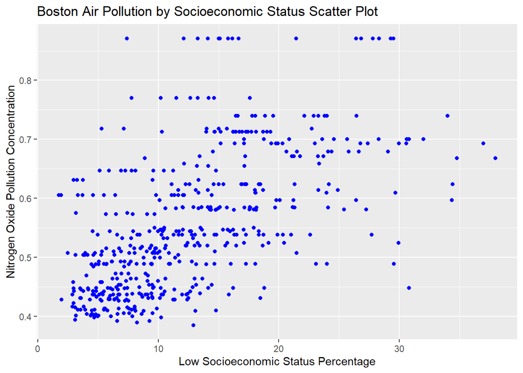

```r
#make a scatter plot of air pollution by socioeconomic status
ggplot(df) +
  geom_point(aes(x = lstat, y = nox), color = "blue") +
  labs(x = "Low Socioeconomic Status Percentage",
       y = "Nitrogen Oxide Pollution Concentration",
       title = "Boston Air Pollution by Socioeconomic Status Scatter Plot")
```

Visually, there seems to be a positive, increasing relationship between low socioeconomic status percentage and nitrogen oxide pollution concentration, but the association is not very strong.

I conduct a linear regression analysis predicting nitrogen oxide pollution concentration from neighborhood low socioeconomic status percentage.

```r
#create simple linear regression model
lm.pollution = lm(nox ~ lstat, data = df)

#get linear regression summary
summary(lm.pollution)
```

```
##
## Call:
## lm(formula = nox ~ lstat, data = df)
##
## Residuals:
##      Min       1Q   Median       3Q      Max
## -0.28079 -0.06262 -0.01816  0.04744  0.36677
##
## Coefficients:
##              Estimate Std. Error t value Pr(>|t|)
## (Intercept) 0.4333754  0.0084703   51.16   <2e-16 ***
## lstat       0.0095882  0.0005831   16.44   <2e-16 ***
## ---
## Signif. codes:  0 '***' 0.001 '**' 0.01 '*' 0.05 '.' 0.1 ' ' 1
##
## Residual standard error: 0.09358 on 504 degrees of freedom
## Multiple R-squared:  0.3491, Adjusted R-squared:  0.3478
## F-statistic: 270.4 on 1 and 504 DF,  p-value: < 2.2e-16
```

Based on the regression coefficient p-value, the relationship between nitrogen oxide pollution concentration and low socioeconomic status percentage of the neighborhood is significant. This conclusion, however, assumes the least squares simple linear regression model is appropriate.

I plot the line produced by fitting the least squared linear regression model to the data.

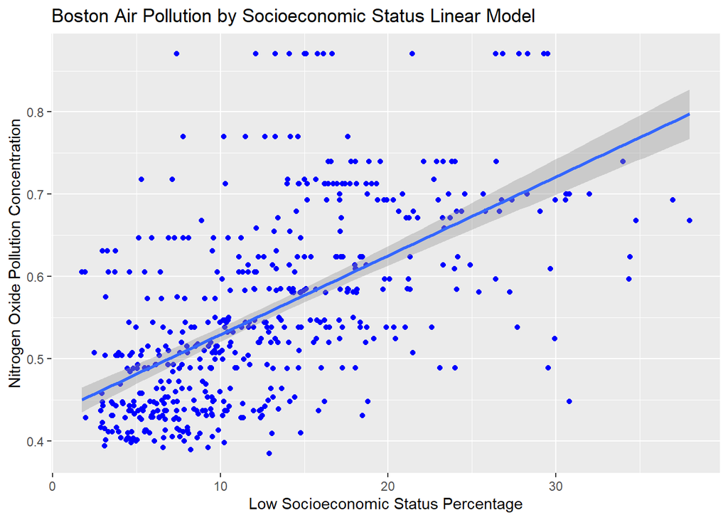

```r
#make a scatter plot of air pollution by socioeconomic status with model
ggplot(df, aes(x = lstat, y = nox)) +
  geom_point(color = "blue") +
  labs(x = "Low Socioeconomic Status Percentage",
       y = "Nitrogen Oxide Pollution Concentration",
       title = "Boston Air Pollution by Socioeconomic Status Linear Model") +
  geom_smooth(method = lm)
```

I now include code to assess whether the linear regression model meets the conditions needed to serve as an accurate portrayal of the relationship.

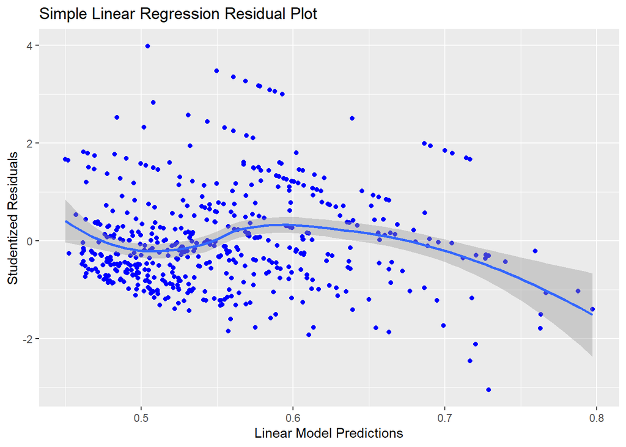

```r
#create a data frame with the predicitions and studentized residuals
df.linassess = data.frame(preds = predict(lm.pollution),
                         resids = rstudent(lm.pollution))

#create residual plot
ggplot(df.linassess, aes(x = preds, y = resids))+
  geom_point(color = "blue") +
  labs(x = "Linear Model Predictions",
       y = "Studentized Residuals",
       title = "Simple Linear Regression Residual Plot") +
  geom_smooth()
```

The data seems slightly nonlinear, but not enough to invalidate my results.